# Visualizing genomic features

Michael Hunt

April 12, 2016

### Genome-wide visualization of peak heights

Elaborate the visualization of GM12878 ESRRA peaks as follows

```r
library(ERBS)
library(ggbio)
```

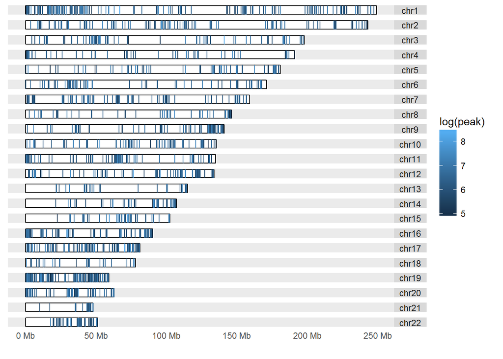

```r
library(GenomeInfoDb)
data(GM12878)
seqlevels(GM12878, force=TRUE) = paste0("chr", 1:22)
  autoplot(GM12878, layout="karyogram", aes(colour=log(peak)))
```

What is the difference between the bars colored in light blue vs those colored in darker blue or black?

light blue bars are located where ESRRA peaks are relatively low  
light blue bars are located where ESRRA peaks are relatively high - correct  
light blue bars correspond to genomic locations with higher probability of ESRRA binding  
light blue bars correspond to genomic locations with lower probability of ESRRA binding

Answer:  
The key is based on the aes(colour=log(peak)) element of the call to autoplot.

### An integrative visualization

The following code combines information on two cell lines and the measured peak values.

```r
library(ERBS)
data(HepG2)
data(GM12878)
HepG2$cell = "HepG2"
GM12878$cell = "Bcell"
tot = c(GM12878, HepG2)
tot$peak10 = tot$peak/10 # copes with automatic scale of y axis
seqlevels(tot, force=TRUE) = paste0("chr", 1:22)
library(ggbio)
library(scales)
```

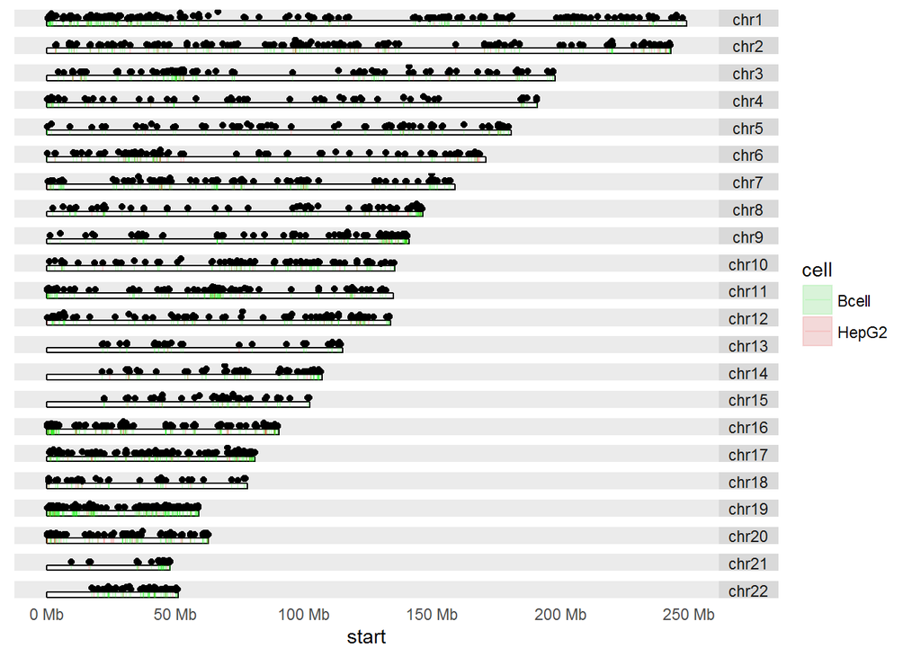

```r
p = autoplot(seqinfo(tot))
p = p + layout_karyogram(tot, aes(fill=cell, colour=cell), geom="rect") +
    scale_colour_manual(values = alpha(c("green", "red"), .1)) +
    scale_fill_manual(values = alpha(c("green", "red"), .1))
p + layout_karyogram(tot, aes(x=start, y=peak10), ylim=c(15,30),
    geom="point", color="blue", size=.8)
```

One chromosome is distinguished in this visualization by exhibiting a unusually dense set of binding events. Perform the following computations after computing tot

```r
stot = split(tot, as.character(seqnames(tot)))
w = sapply(stot, function(x) sum(width(x)))
sort(w/seqlengths(tot)[names(w)])
```

```
##        chr13         chr4         chr5        chr18         chr3
## 0.0003640188 0.0004506674 0.0006031774 0.0006339747 0.0007702410
##         chr6         chr8        chr14        chr15        chr21
## 0.0007922155 0.0007992880 0.0008041301 0.0008168035 0.0008297961
##         chr2        chr10         chr7         chr9        chr12
## 0.0008607670 0.0008858319 0.0009302705 0.0009381261 0.0010232055
##        chr11         chr1        chr22        chr20        chr16
## 0.0011309380 0.0013064441 0.0017759823 0.0018399690 0.0022556755
##        chr17        chr19
## 0.0023735513 0.0050610713
```

Pick the chromosome with the greatest density of ESRRA binding sites.

chr1  
chr5  
chr19 - correct chr17  
chr13  
chr21

### Multitrack visualization function

Add the following function to your workspace:

```r
showz = function (sym = "ESRRA", radius = 1e+05)
{
    require(ggbio)
    require(erma)
    require(ERBS)
    es = genemodel(sym)
    data(HepG2)
    data(GM12878)
    hsub = subsetByOverlaps(HepG2, es + radius)
    gsub = subsetByOverlaps(GM12878, es + radius)
    tracks(gene = es, hepNarr = autoplot(hsub), gmNarr = autoplot(gsub),
        title = sym)
}
```

You can run the function with defaults, generating and viewing a ggbio object:

```r
p = showz()
```

```
## Now getting the GODb Object directly
```

```
## Now getting the OrgDb Object directly
```

```
## Now getting the TxDb Object directly
```

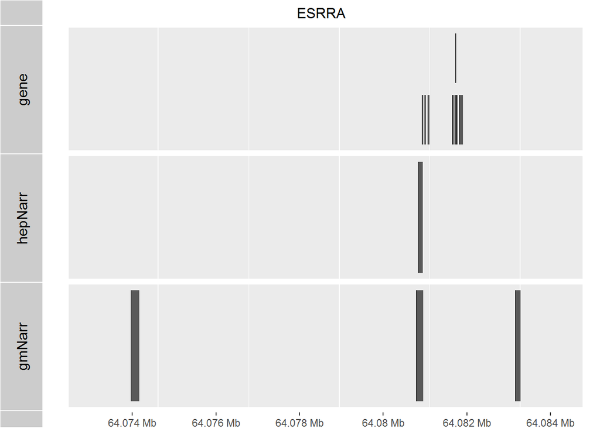

```r
p
```

What is the value of the rightmost x-axis tick in this display?

64.06 Mb  
64.074 Mb  
64.084 Mb - correct  
63.95 Mb

### Incremental zooming into/out of display with ggbio

A nice feature of the ggbio/ggplot2 framework is the availability of the state of the display for modification using operators. Try

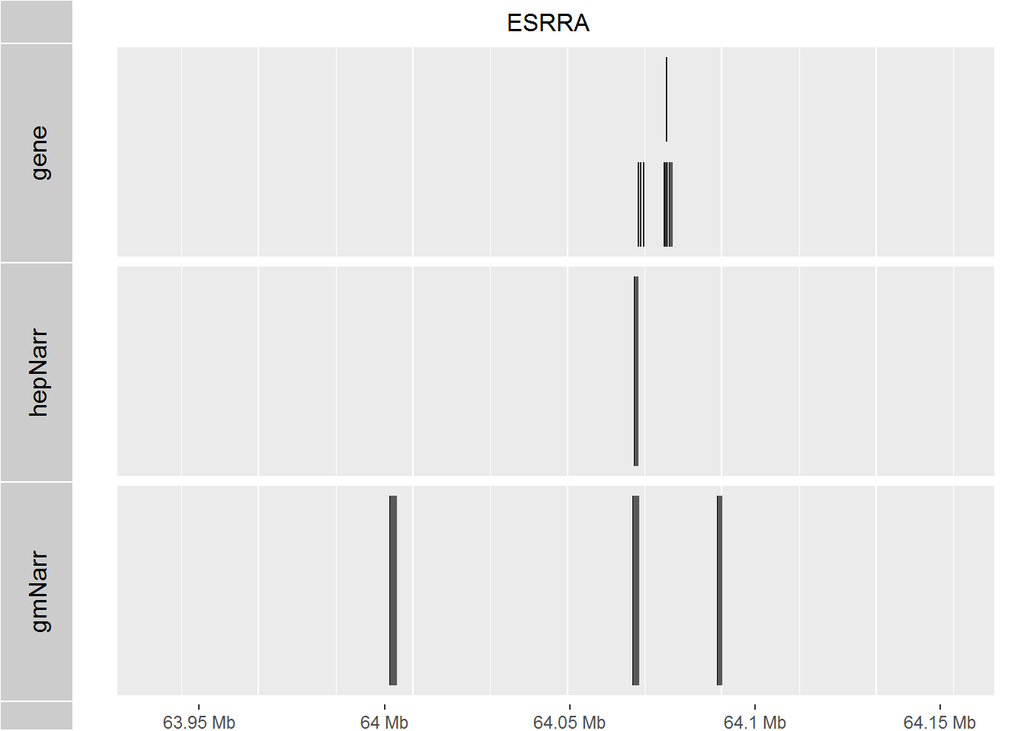

```r
p+zoom(2)
```

Now what is the leftmost tick mark value on the x-axis?

64.02 Mb  
64.084 Mb  
63.95 Mb  
64.074 Mb

### Using the debugger with a troublesome gene

Use showz to view the binding patterns near the gene oncomodulin (OCM). It will fail with the default radius, so try again with radius = 2e6. But before running it, issue

```r
debug(showz)
```

Step through the code after issuing

```r
showz("OCM", radius=2e6)
```

How many ranges are present in the GRanges variable gsub? You can mention it in the debugger after it is computed.

Answer: 9. With r=2e6, `showz` crashes Try

```r
subsetByOverlaps(GM12878, genemodel("OCM")+2e6)
```

```
## GRanges object with 9 ranges and 7 metadata columns:
##       seqnames             ranges strand |      name     score       col
##          <Rle>          <IRanges>  <Rle> | <numeric> <integer> <logical>
##   [1]     chr7 [5468427, 5470244]      * |      1245         0      <NA>
##   [2]     chr7 [6677218, 6677897]      * |      1632         0      <NA>
##   [3]     chr7 [5631786, 5632978]      * |      1703         0      <NA>
##   [4]     chr7 [6048003, 6049346]      * |      1109         0      <NA>
##   [5]     chr7 [6629307, 6630548]      * |      4521         0      <NA>
##   [6]     chr7 [5526170, 5528037]      * |      3259         0      <NA>
##   [7]     chr7 [5013131, 5014286]      * |      1994         0      <NA>
##   [8]     chr7 [4793359, 4793958]      * |     10557         0      <NA>
##   [9]     chr7 [6143958, 6144757]      * |      2791         0      <NA>
##       signalValue    pValue    qValue      peak
##         <numeric> <numeric> <numeric> <integer>
##   [1]       12.68    23.721   2.09691       719
##   [2]       11.81    20.571   2.09691       322
##   [3]        10.5    20.155  2.119186       710
##   [4]       10.06    24.922  2.045757      1011
##   [5]        9.62    11.568  1.266001       313
##   [6]        8.84    14.278  1.815309       495
##   [7]        8.75    18.631   2.09691       385
##   [8]        8.72     6.269  0.011976       341
##   [9]         8.7    15.555  2.013228       417
##   -------
##   seqinfo: 93 sequences (1 circular) from hg19 genome
```

```r
subsetByOverlaps(GM12878, genemodel("OCM")+5e6)
```

```
## GRanges object with 15 ranges and 7 metadata columns:
##        seqnames             ranges strand   |      name     score
##           <Rle>          <IRanges>  <Rle>   | <numeric> <integer>
##    [1]     chr7 [2676483, 2677843]      *   |       546         0
##    [2]     chr7 [1609209, 1610399]      *   |       687         0
##    [3]     chr7 [5468427, 5470244]      *   |      1245         0
##    [4]     chr7 [6677218, 6677897]      *   |      1632         0
##    [5]     chr7 [1014437, 1015932]      *   |       881         0
##    ...      ...                ...    ... ...       ...       ...
##   [11]     chr7 [2139362, 2140939]      *   |      3957         0
##   [12]     chr7 [5526170, 5528037]      *   |      3259         0
##   [13]     chr7 [5013131, 5014286]      *   |      1994         0
##   [14]     chr7 [4793359, 4793958]      *   |     10557         0
##   [15]     chr7 [6143958, 6144757]      *   |      2791         0
##              col signalValue    pValue    qValue      peak
##        <logical>   <numeric> <numeric> <numeric> <integer>
##    [1]      <NA>       20.55    35.365  1.958607       786
##    [2]      <NA>       12.68    31.324  1.935542       550
##    [3]      <NA>       12.68    23.721   2.09691       719
##    [4]      <NA>       11.81    20.571   2.09691       322
##    [5]      <NA>       11.37    27.741  1.943095       297
##    ...       ...         ...       ...       ...       ...
##   [11]      <NA>        9.43     12.69  1.528708       644
##   [12]      <NA>        8.84    14.278  1.815309       495
##   [13]      <NA>        8.75    18.631   2.09691       385
##   [14]      <NA>        8.72     6.269  0.011976       341
##   [15]      <NA>         8.7    15.555  2.013228       417
##   -------
##   seqinfo: 93 sequences (1 circular) from hg19 genome
```

from within the `showz` function. With radius 2e6 hsub evaluates to zero and showz crashes. Use of debugger allows us to spot this.

### Preparing modifications to esrraScan: accommodating multiple peak sets

Here is the text of the esrraScan function with line numbers. We’d like to allow visualization of multiple peak sets, for example, both HepG2 and GM12878 in the same display.

`1 esrraScan = function (sym = "ESRRA", bindingGR, radius = 500000) 2 { 3 require(ERBS) 4 require(Gviz) 5 require(Homo.sapiens) 6 require(TxDb.Hsapiens.UCSC.hg19.knownGene) 7 txdb = TxDb.Hsapiens.UCSC.hg19.knownGene 8 eid = select(Homo.sapiens, keys = sym, keytype = "SYMBOL", 9 columns = "ENTREZID") 10 allg = genes(txdb) 11 must_concat = FALSE 12 curgAddr = genes(txdb, single.strand = FALSE, vals = list(gene_id = eid$ENTREZID))[[1]] 13 if (length(curgAddr) > 1) { 14 must_concat = TRUE 15 curgAddr$gene_id = eid$ENTREZID 16 curgAddr = curgAddr[which(as.character(seqnames(curgAddr)) %in% 17 paste0("chr", c(1:22, "X", "Y")))[1]] 18 } 19 curgNeigh = subsetByOverlaps(allg, curgAddr + radius) 20 if (must_concat) 21 curgNeigh = c(curgNeigh, curgAddr) 22 curgNeigh$symbol = mapIds(Homo.sapiens, keys = curgNeigh$gene_id, 23 keytype = "ENTREZID", column = "SYMBOL") 24 sc = subsetByOverlaps(bindingGR, range(curgNeigh)) 25 message("getting ideogram...") 26 idxTrack = IdeogramTrack(genome = "hg19", chr = as.character(seqnames(curgNeigh[1]))) 27 message("done.") 28 plotTracks(list(idxTrack, GenomeAxisTrack(), DataTrack(sc[, 29 7], name = "ESRRA peak values"), GeneRegionTrack(curgNeigh, 30 showId = TRUE, name = paste("genes near", sym)), GenomeAxisTrack())) 31 }` At which line number is the genome-wide binding data restricted to the neighborhood of the gene of interest?